# Example R code notebook

## Keagan DeLong

The notebook explores traffic at the Port of Los Angeles, inspiration for the project came from the highly publicized backlog of traffic in 2021.

## The Data

This project will analyze a dataset from the Port of Los Angeles, particularly total twenty-foot units of cargo. The dataset contains values from Janurary 2000 - December 2020. The purpose of this analysis is to test a hypothesized claim that we can compare the patterns of cargo during the 2008 Economic Crisis to the current supply chain issues we are experiencing in 2021.

The data is subsetted into the years surrounding the economic crisis. We seek to find that a reasonable correlation exists between the two events such that the trends produced during the recovery years after 2008 can be a reliable way to model the future.

Data was retrived from the Port of Los Angeles's website. The data is freely available to anyone though I have compiled it into a single comma separated values document and changed the date to an recognized ISO date format. The data can be viewed [here](https://www.portoflosangeles.org/business/statistics/container-statistics).

The first step in this analysis is importing nessessary packages to handle and interpret the data. The data was already cleaned and formatted in Microsoft Excel to simpify the process.

```r
install.packages(c("zoo","tidyverse","forecast", "TSstudio", "fitdistrplus"))
```

```r
lapply(c("zoo","tidyverse","forecast", "TSstudio", "fitdistrplus"), require, character.only = T)
```

1. TRUE

2. TRUE

3. TRUE

4. TRUE

5. TRUE

Here we load in the dataset and format the columns we want to analyze in the R timeseries format. Moreover, we insure that the dates are in an acceptable format for easy of data processing while maintaining an acceptable ISO format. In the timeseries we specify that the frequency of the data is formatted in 12 month increments form the year 2000.

```r
handler <- read.csv("pola-container-statistics-2000-2020.csv", header = T)
container_stats <- handler[1:8]
container_stats$Date <- as.Date(as.yearmon(container_stats$Date, "%Y-%m", frac = 1))
container_stats_ts <- ts(container_stats, start = 2000, frequency = 12)
```

Further more the first steps of analyzing the data is going to be to plot the whole dataset to visually inspect the data.

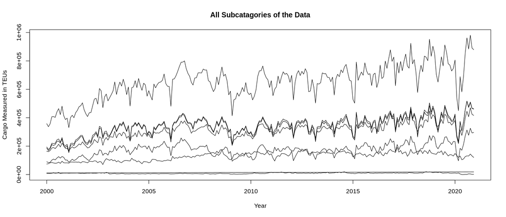

```r
options(repr.plot.width=14, repr.plot.height=6, repr.plot.res = 125)
ts.plot(container_stats_ts, xlab = "Year",
ylab = "Cargo Measured in TEUs",
main = "All Subcatagories of the Data")
```

The first subset of the dataset we want is going to be the columns that contains the total TEUs recorded. This column is the addition of the total imports and exports of cargo.

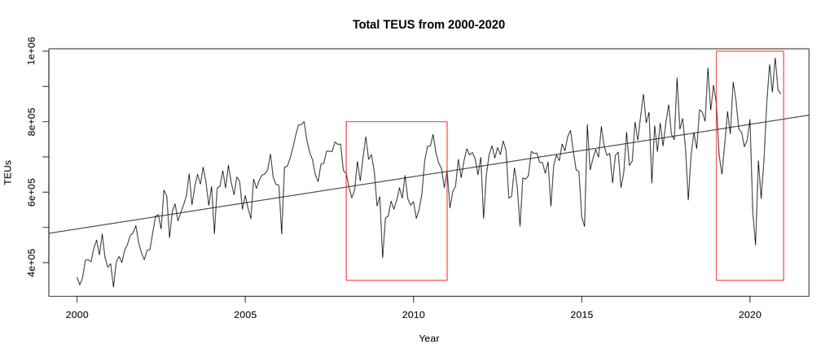

```r
total_teus <- ts(container_stats$Total.TEUs, start = 2000, frequency = 12)
ts.plot(total_teus, xlab = "Year",
 ylab = "TEUs",
 main = "Total TEUS from 2000-2020")
 abline(reg = lm(total_teus~time(total_teus)))


x <- c(2008,2008, 2011, 2011)
y <- c(350000,800000,800000,350000)
polygon(x, y, density = 0, col = "red")

xx <- c(2019,2019, 2021, 2021)
yy <- c(350000,1000000,1000000,350000)
polygon(xx, yy, density = 0, col = "red")
```

```r
crisis1_36 <- window(total_teus, start = 2008, end = c(2010,12))
crisis1 <- window(total_teus, start = 2008, end = c(2009,12))
crisis2 <- window(total_teus, start = 2019, end = c(2020,12))
length(crisis1_36)
length(crisis1)
length(crisis2)
```

36

24

24

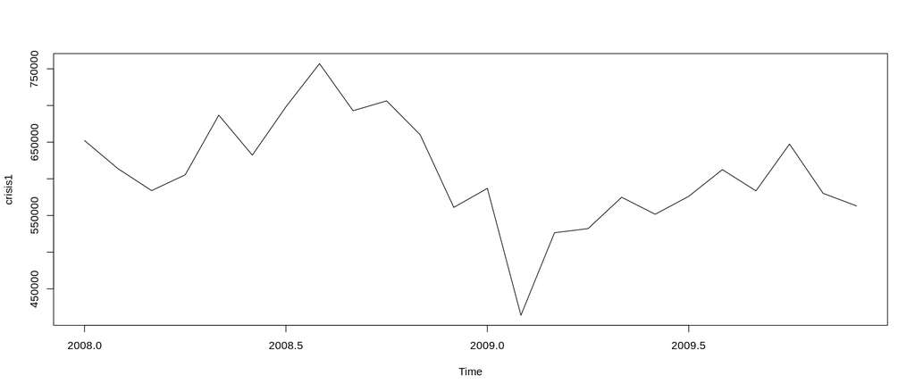

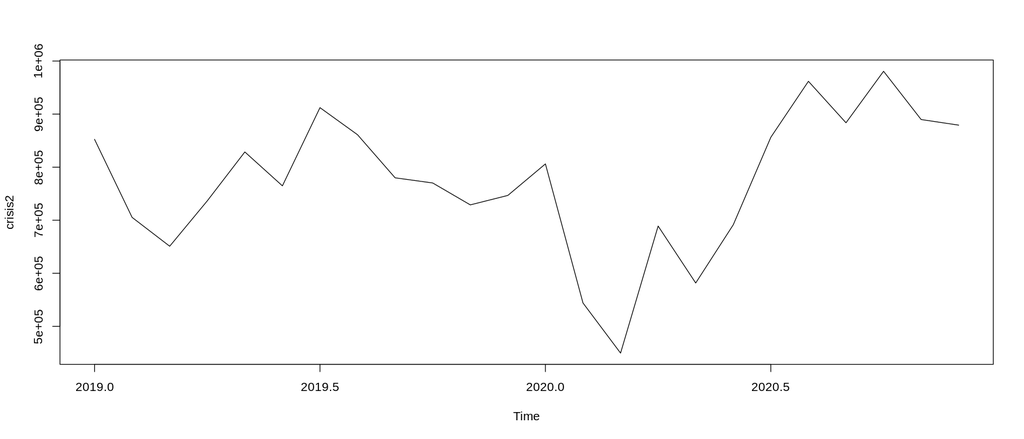

```r
ts.plot(crisis1)
ts.plot(crisis2)
```

Now that we have the two windows of time we want to compare lets collect some descriptive statistics on the numbers

```r
summary(total_teus)
summary(crisis1)
summary(crisis2)

sd(total_teus)
sd(crisis1)
sd(crisis2)

var(total_teus)
var(crisis1)
var(crisis2)
```

```
   Min. 1st Qu.  Median    Mean 3rd Qu.    Max.
 330431  577450  662188  650820  725388  980729
```

```
   Min. 1st Qu.  Median    Mean 3rd Qu.    Max.
 413910  571868  596235  608291  654189  757069
```

```
   Min. 1st Qu.  Median    Mean 3rd Qu.    Max.
 449568  701849  775046  772960  865607  980729
```

125306.970556713

72915.5563060031

130457.891293562

15701836870.1009

5316678351.41391

17019261400.7629

|  | Min. | 1st Qu. | Median | Mean | 3rd Qu. | Max. | Sd | Var |
| --- | --- | --- | --- | --- | --- | --- | --- | --- |
| Total | 330431 | 577450 | 662188 | 650820 | 725388 | 980729 | 125306.97 | 15701836870.10 |
| 2008-2009 | 413910 | 571868 | 596235 | 608291 | 654189 | 757069 | 72915.56 | 5316678351.41 |
| 2019-2020 | 449568 | 701849 | 775046 | 772960 | 865607 | 980729 | 130457.89 | 17019261400.76 |

```r
cor(crisis1, crisis2)
```

0.541011298888554

Our correlation coeffienct is approximately 0.54. This tells us there is a moderate correlation between the two time periods. Later we will dermine if there is a forecasted patern that can maintain or outperform this correlation coefficent.

## Forecasting

### ARMA Forecast

```r
AutoArimaTotal <- auto.arima(total_teus)
summary(AutoArimaTotal)
```

```
Series: total_teus
ARIMA(0,1,1)(0,0,2)[12]

Coefficients:
          ma1    sma1    sma2
      -0.5193  0.2184  0.3836
s.e.   0.0621  0.0645  0.0684

sigma^2 estimated as 3.866e+09:  log likelihood=-3127.34
AIC=6262.68   AICc=6262.85   BIC=6276.79

Training set error measures:
                   ME     RMSE      MAE        MPE     MAPE      MASE
Training set 3017.836 61683.14 45907.05 -0.1972818 7.266832 0.6801175
                     ACF1
Training set -0.001960245
```

```r
total_arma <- arima(total_teus, order = c(0,1,1))
```

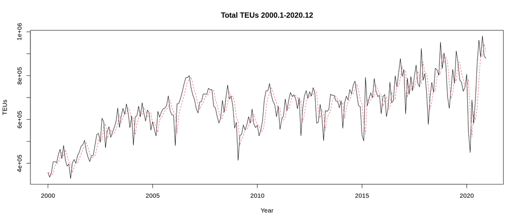

```r
ts.plot(total_teus, xlab = "Year",
 ylab = "TEUs",
 main = "Total TEUs 2000.1-2020.12")
total_arma_fit <- total_teus - residuals(total_arma)
points(total_arma_fit, type = "l", col = 2, lty = 2)
```

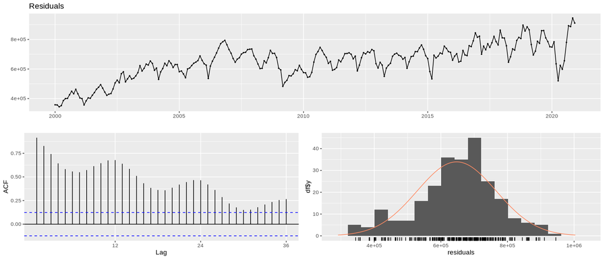

```r
checkresiduals(total_arma_fit)
```

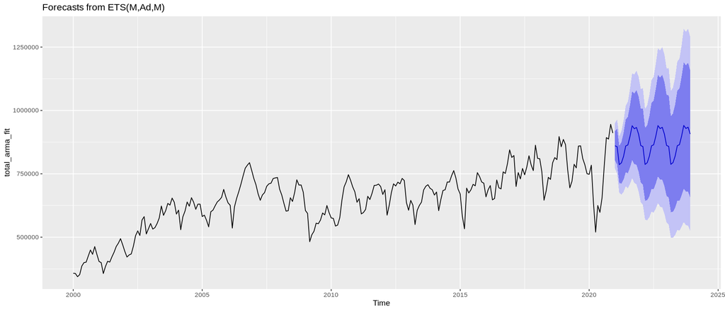

```r
autoplot(forecast(total_arma_fit, 36))
```

```r
teu_forecast <- forecast(total_arma_fit, 36)
lower_forecast <- as.data.frame(teu_forecast$lower)
upper_forecast <- as.data.frame(teu_forecast$upper)

forecast_df <- container_stats$Total.TEUs

upper95_ts <- ts(c(forecast_df, upper_forecast$`95%`), start = 2000, frequency = 12)
upper80_ts <- ts(c(forecast_df, upper_forecast$`80%`), start = 2000, frequency = 12)
lower80_ts <- ts(c(forecast_df, lower_forecast$`80%`), start = 2000, frequency = 12)
lower95_ts <- ts(c(forecast_df, lower_forecast$`95%`), start = 2000, frequency = 12)
```

#### Testing

```r
test <- as.vector(window(total_teus, start = 2008, end = c(2012,12)))
test_upper95 <- as.vector(window(upper95_ts, start = 2019, end = c(2023,12)))
test_upper80 <- as.vector(window(upper80_ts, start = 2019, end = c(2023,12)))
test_lower80 <- as.vector(window(lower80_ts, start = 2019, end = c(2023,12)))
test_lower95 <- as.vector(window(lower95_ts, start = 2019, end = c(2023,12)))
```

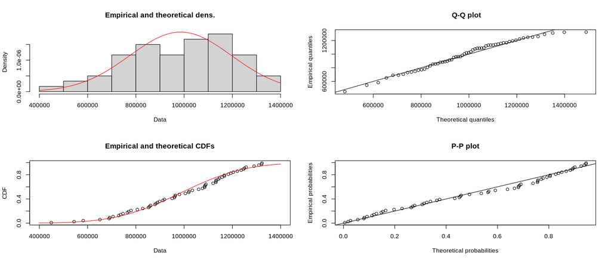

```r
dist1 <- fitdist(test_upper95, "norm")
plot(dist1)
```

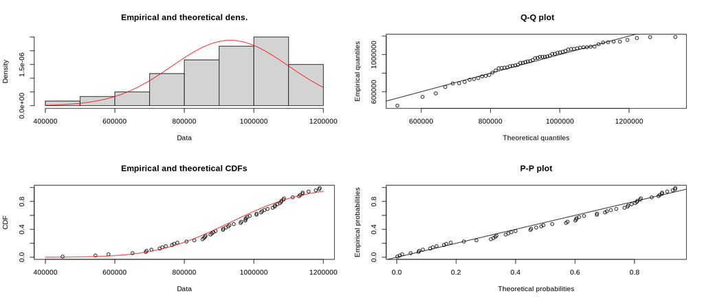

```r
dist2 <- fitdist(test_upper80, "norm")
plot(dist2)
```

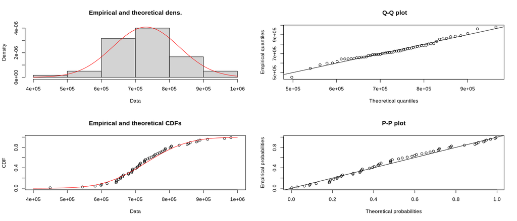

```r
dist3 <- fitdist(test_lower80, "norm")
plot(dist3)
```

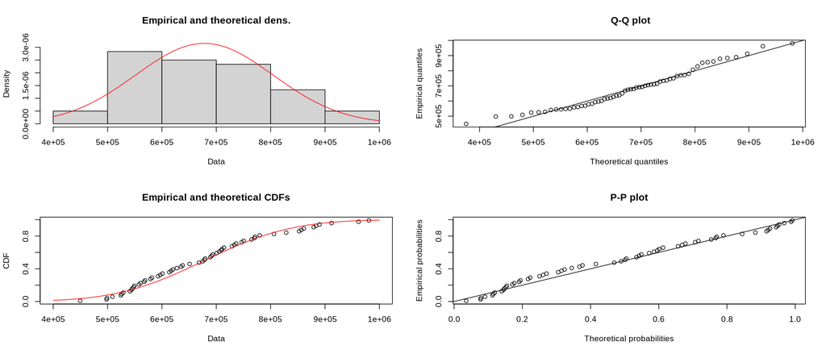

```r
dist4 <- fitdist(test_lower95, "norm")
plot(dist4)
```

```r
cor(test,test_upper95)
cor(test,test_upper80)
cor(test,test_lower80)
cor(test,test_lower95)
```

0.532039709487711

0.546067701601492

0.142743476314291

-0.0521074789054615

```r
summary(test_upper80)
sd(test_upper80)
var(test_upper95)
```

```
   Min. 1st Qu.  Median    Mean 3rd Qu.    Max.
 449568  846503  962860  932334 1062674 1189559
```

169041.357089081

45123962038.7185

[output not shown]

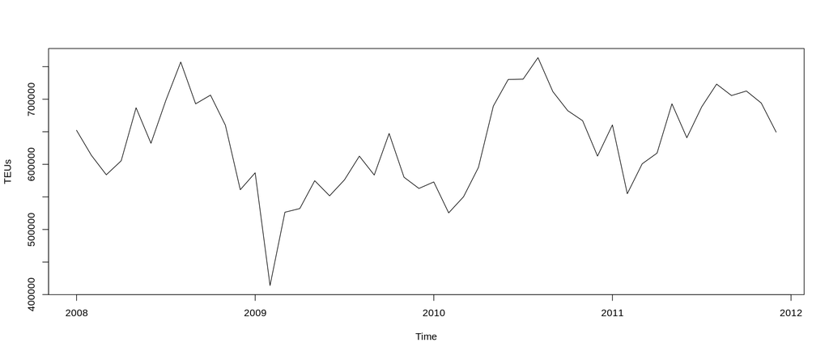

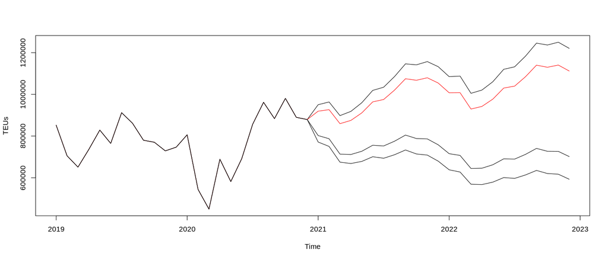

```r
plot(window(total_teus, start = 2008, end = c(2011,12)), ylab = "TEUs")

plot(window(upper95_ts, start = 2019, end = c(2022,12)), ylab = "TEUs")
lines(window(upper80_ts, start = 2019, end = c(2022,12)), col = "red")
lines(window(lower80_ts, start = 2019, end = c(2022,12)))
lines(window(lower95_ts, start = 2019, end = c(2022,12)))
```

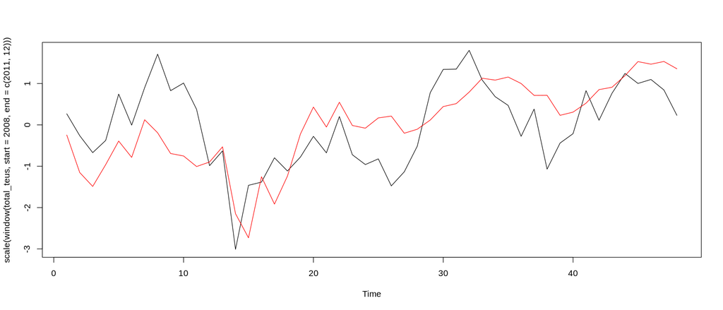

```r
ts.plot(scale(window(total_teus, start = 2008, end = c(2011,12))))
lines(scale(window(upper80_ts, start = 2019, end = c(2022,12))), col = "red")
```

Above we have illustrated that we found a reasonable forecasted distribution that can maintain the correlation coefficent.